# MP_SRF_amplicons_18S_and_16S_diversity_analysis

lrubinat

05/03/2016

# 1) 18S amplicons

## 1.1) Data overview

Let’s read the dataset and remove the samples containing less than 8522 reads:

```
## [1] 47144   130
```

```
##   OTUId st001 st002 st003 st004
## 1 OTU_1   469   187   240   135
## 2 OTU_2   445   389   760   819
## 3 OTU_3  1030  2196  1611   453
## 4 OTU_4   135    66    36   365
## 5 OTU_5     0   178   285   175
```

```
## [1] 47144   129
```

```
##       st001 st002 st003 st004 st005
## OTU_1   469   187   240   135   184
## OTU_2   445   389   760   819  1003
## OTU_3  1030  2196  1611   453   512
## OTU_4   135    66    36   365   146
## OTU_5     0   178   285   175    49
```

```
## [1] 47144     7
```

```
##                                                                                                                          SILVA_taxonomic_classification
## OTU_1         KC488417.1.1688_Eukaryota;SAR;Alveolata;Dinoflagellata;Dinophyceae;Gymnodiniphycidae;Gymnodinium_clade;FV18-2D9;uncultured_dinoflagellate
## OTU_2                              FJ832119.1.1585_Eukaryota;SAR;Alveolata;Protalveolata;Syndiniales;Syndiniales_Group_I;uncultured_marine_picoplankton
## OTU_3                                       EF172960.1.1674_Eukaryota;SAR;Alveolata;Protalveolata;Syndiniales;Syndiniales_Group_II;uncultured_eukaryote
## OTU_4 KC488405.1.1558_Eukaryota;SAR;Alveolata;Dinoflagellata;Dinophyceae;Gymnodiniphycidae;Gymnodinium_clade;Erythropsidinium;uncultured_dinoflagellate
## OTU_5                                      EU793901.1.1663_Eukaryota;SAR;Alveolata;Protalveolata;Syndiniales;Syndiniales_Group_I;uncultured_syndiniales
##         MAS_taxonomic_classification   BM_taxonomic_classification
## OTU_1 EU793855_Dinophyceae_Alveolata 9492_Dinophyceae_Alveolata_15
## OTU_2      EU793773_MALV-I_Alveolata     3261_MALV-I_Alveolata_385
## OTU_3     EU793316_MALV-II_Alveolata                          <NA>
## OTU_4 EU780636_Dinophyceae_Alveolata 21474_Dinophyceae_Alveolata_6
## OTU_5      EU818388_MALV-I_Alveolata      398_MALV-I_Alveolata_395
##       SILVA_class   MAS_class    BM_class MAS_plus_BM_plus_SILVA_class
## OTU_1 Dinophyceae Dinophyceae Dinophyceae                  Dinophyceae
## OTU_2        <NA>        <NA>        <NA>                         <NA>
## OTU_3        <NA>        <NA>        <NA>                         <NA>
## OTU_4 Dinophyceae Dinophyceae Dinophyceae                  Dinophyceae
## OTU_5        <NA>        <NA>        <NA>                         <NA>
```

```
## [1] 47144   122
```

```
##       st001 st002 st003 st004 st005
## OTU_1   469   187   240   135   184
## OTU_2   445   389   760   819  1003
## OTU_3  1030  2196  1611   453   512
## OTU_4   135    66    36   365   146
## OTU_5     0   178   285   175    49
```

```
## st054
##  4050
```

```
## [1] 47144   121
```

```
## [1] 47144   117
```

```
## [1] 47144     0
```

Table dimensions and content outline:

```
## [1] 47144   117
```

```
##       st001 st002 st003 st004 st005
## OTU_1   469   187   240   135   184
## OTU_2   445   389   760   819  1003
## OTU_3  1030  2196  1611   453   512
## OTU_4   135    66    36   365   146
## OTU_5     0   178   285   175    49
```

Minimum number of reads per station:

```r
min(colSums(tb18_tax_occur_min8522))
```

```
## [1] 8522
```

Maximum number of reads per station:

```r
max(colSums(tb18_tax_occur_min8522))
```

```
## [1] 936570
```

Identification of station with higher number of reads:

```r
amplicons_per_sample<-colSums(tb18_tax_occur_min8522)
amplicons_per_sample[which(colSums(tb18_tax_occur_min8522)>900000)]
```

```
##  st131
## 936570
```

Overall reads per sample:

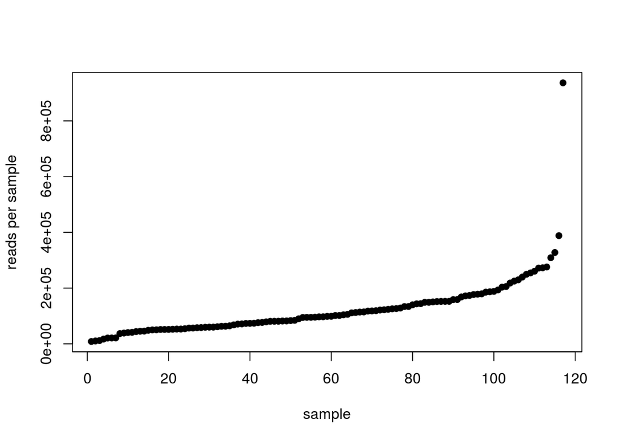

## 1.2) Normalization

Let’s normalize the original dataset by randomly subsampling 8522 reads in each station:

```r
library(vegan)
tb18_tax_occur_min8522_t<-t(tb18_tax_occur_min8522)
tb18_tax_occur_ss8522<-rrarefy(tb18_tax_occur_min8522_t, 8522)
```

The normalized table shows the following dimensions and format:

```
## [1]   117 47144
```

```
##       OTU_1 OTU_2 OTU_3 OTU_4 OTU_5
## st001    26    25    49     8     0
## st002    23    44   241     3    24
## st003    34   131   237     2    48
## st004    37   189    94   102    31
## st005    24   141    76    32     8
```

Its content fits with the expected normalization values (8522 reads per station):

```r
rowSums(tb18_tax_occur_ss8522)
```

```
## st001 st002 st003 st004 st005 st007 st009 st010 st012 st013 st014 st015
##  8522  8522  8522  8522  8522  8522  8522  8522  8522  8522  8522  8522
## st017 st018 st019 st022 st023 st024 st025 st026 st027 st028 st029 st030
##  8522  8522  8522  8522  8522  8522  8522  8522  8522  8522  8522  8522
## st032 st033 st034 st035 st037 st038 st039 st040 st041 st043 st044 st045
##  8522  8522  8522  8522  8522  8522  8522  8522  8522  8522  8522  8522
## st046 st047 st049 st050 st051 st052 st053 st055 st056 st057 st058 st059
##  8522  8522  8522  8522  8522  8522  8522  8522  8522  8522  8522  8522
## st060 st062 st063 st064 st065 st066 st067 st068 st069 st070 st071 st072
##  8522  8522  8522  8522  8522  8522  8522  8522  8522  8522  8522  8522
## st073 st074 st075 st076 st077 st078 st079 st081 st082 st083 st085 st086
##  8522  8522  8522  8522  8522  8522  8522  8522  8522  8522  8522  8522
## st087 st088 st089 st092 st093 st094 st095 st096 st097 st098 st101 st102
##  8522  8522  8522  8522  8522  8522  8522  8522  8522  8522  8522  8522
## st103 st104 st106 st107 st108 st109 st110 st112 st114 st115 st116 st118
##  8522  8522  8522  8522  8522  8522  8522  8522  8522  8522  8522  8522
## st119 st120 st121 st125 st126 st127 st128 st129 st130 st131 st132 st133
##  8522  8522  8522  8522  8522  8522  8522  8522  8522  8522  8522  8522
## st134 st135 st138 st139 st140 st141 st143 st145 st146
##  8522  8522  8522  8522  8522  8522  8522  8522  8522
```

Let’s check out how many OTUs don’t appear in the new table:

```r
length(which(colSums(tb18_tax_occur_ss8522)==0))
```

```
## [1] 20431
```

```r
tb18_tax_occur_ss8522_no_cero<-tb18_tax_occur_ss8522[,-(which(colSums(tb18_tax_occur_ss8522)==0))]
dim(tb18_tax_occur_ss8522_no_cero)
```

```
## [1]   117 26713
```

## 1.3) General community analysis

### 1.3.1) Richness and evenness (Shannon index)

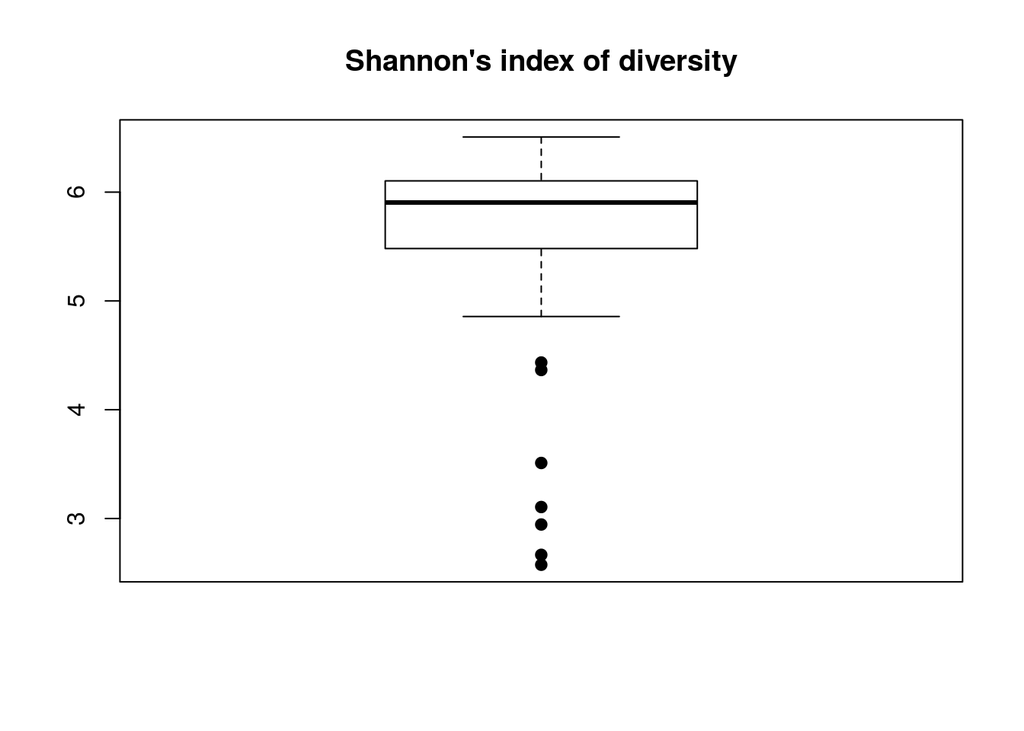

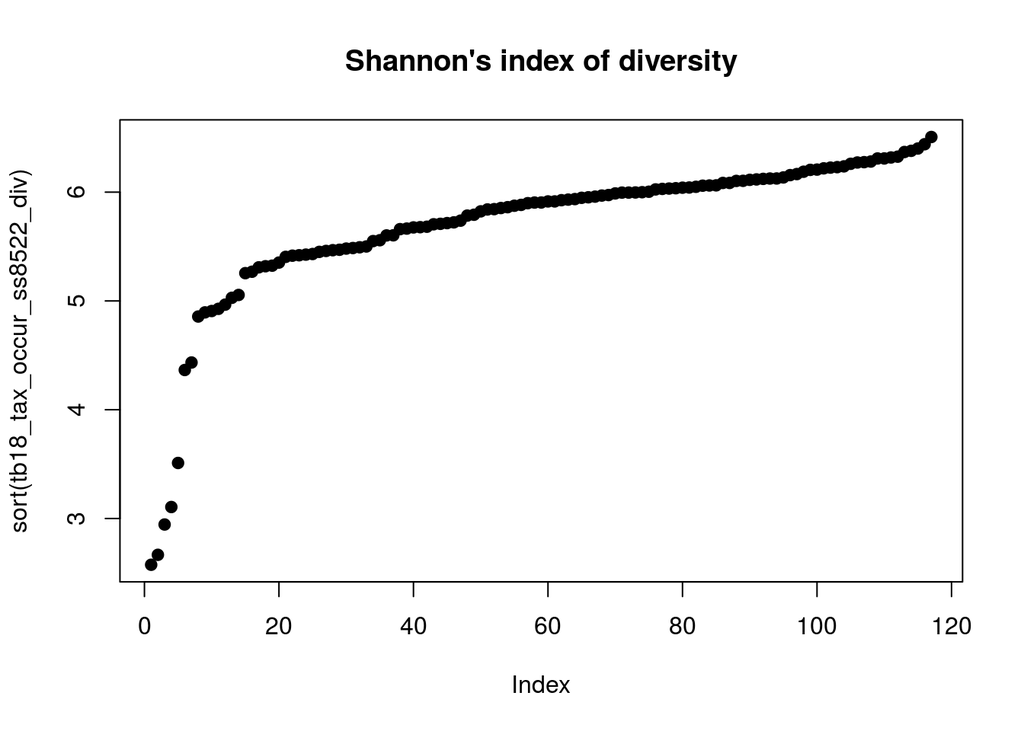

### 1.3.2) Richness: OTU number

Lowest number of OTUs per sample:

```
## [1] 168
```

Maximum number of OTUs per sample:

```
## [1] 1986
```

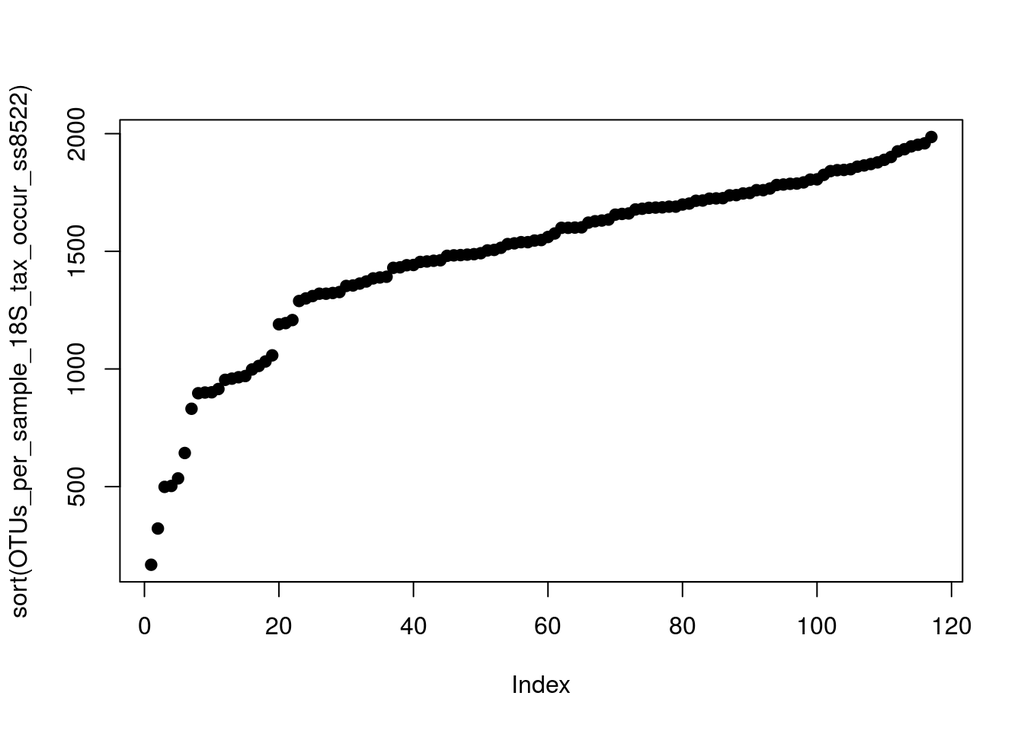

```r
plot(sort(OTUs_per_sample_18S_tax_occur_ss8522), pch=19)
```

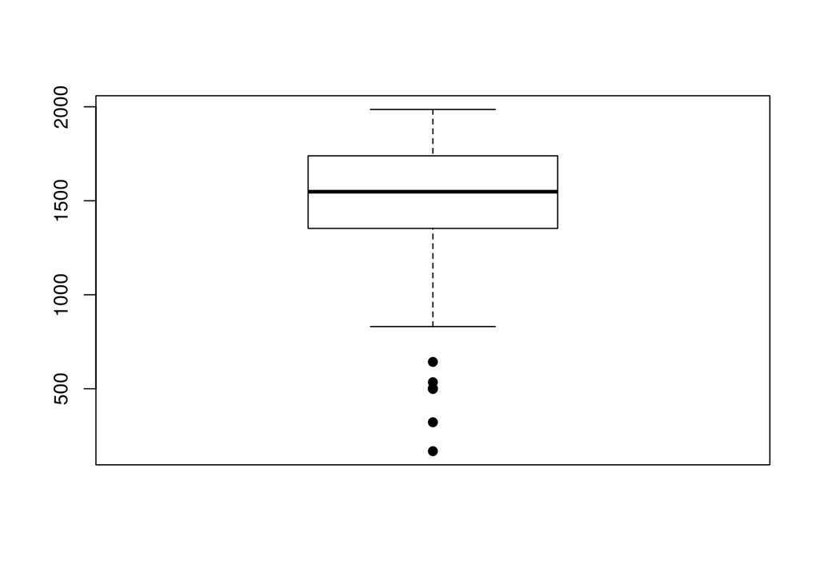

```r
boxplot(OTUs_per_sample_18S_tax_occur_ss8522, pch=19)
```

### 1.3.3) Index of evenness

#### 1.3.3.1) Pielou’s index

```r
pielou_evenness_18S_tax_occur_ss8522 <- tb18_tax_occur_ss8522_div/log(OTUs_per_sample_18S_tax_occur_ss8522)
```

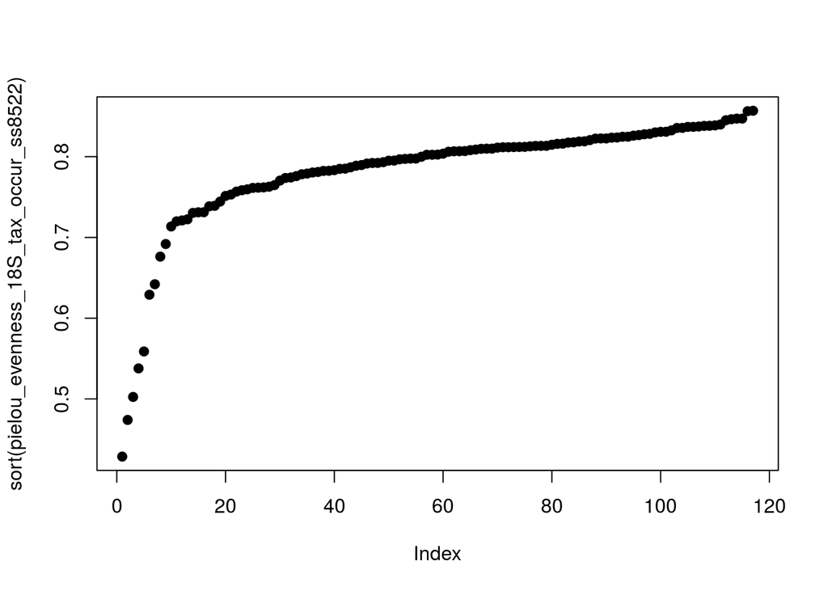

```r
plot(sort(pielou_evenness_18S_tax_occur_ss8522), pch=19)
```

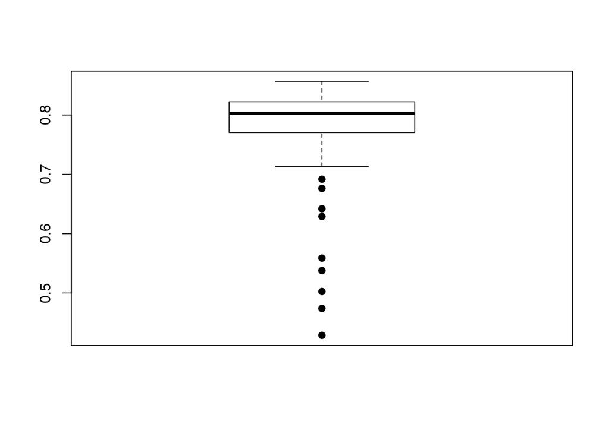

```r
boxplot(pielou_evenness_18S_tax_occur_ss8522, pch=19)
```

```r
head(sort(colSums(tb18_tax_occur_ss8522_no_cero), decreasing=T), n=10L)
```

```
##  OTU_2  OTU_6 OTU_23  OTU_8 OTU_25 OTU_27  OTU_1 OTU_12  OTU_9  OTU_7
##  48439  35256  12264  11760  10044   9850   8568   8022   7937   7600
```

Most of the OTUs show very few occurrences; the plot suggests that we will probably be able to identify a significant ammount of rare otus:

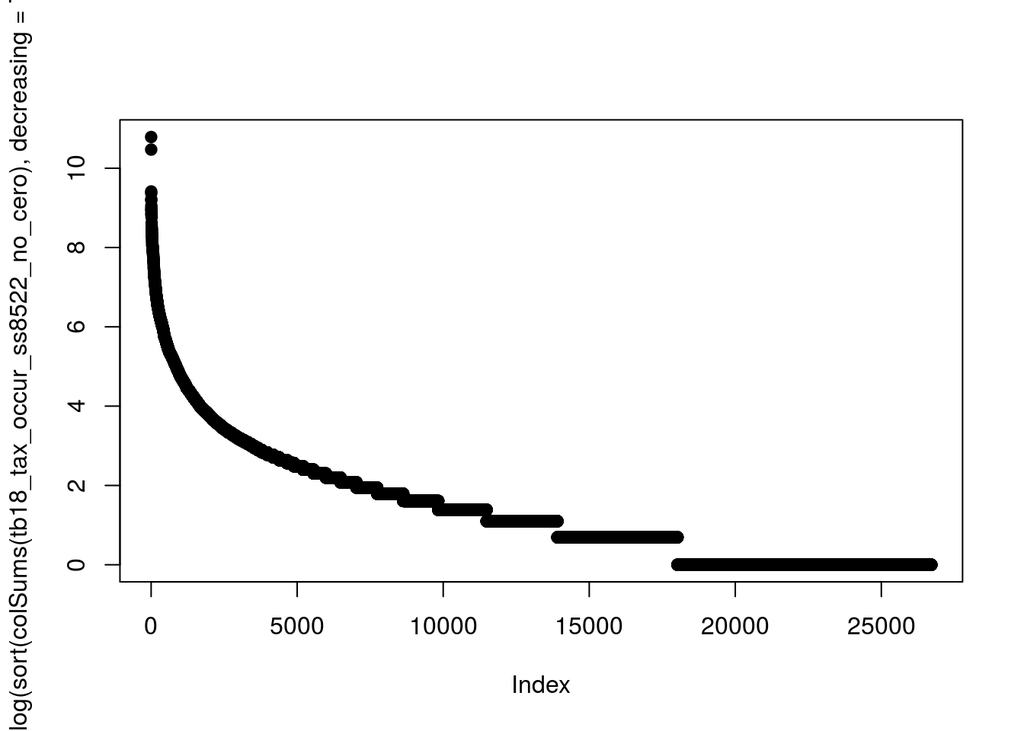

```r
plot(log(sort(colSums(tb18_tax_occur_ss8522_no_cero), decreasing=T)), pch=19)
```

### 1.3.4) Abundance Models

#### 1.3.4.1) Rank-Abundance or Dominance/Diversity Model (“radfit”)

The OTUs abundance distribution fits relativelly close to log-normal model.

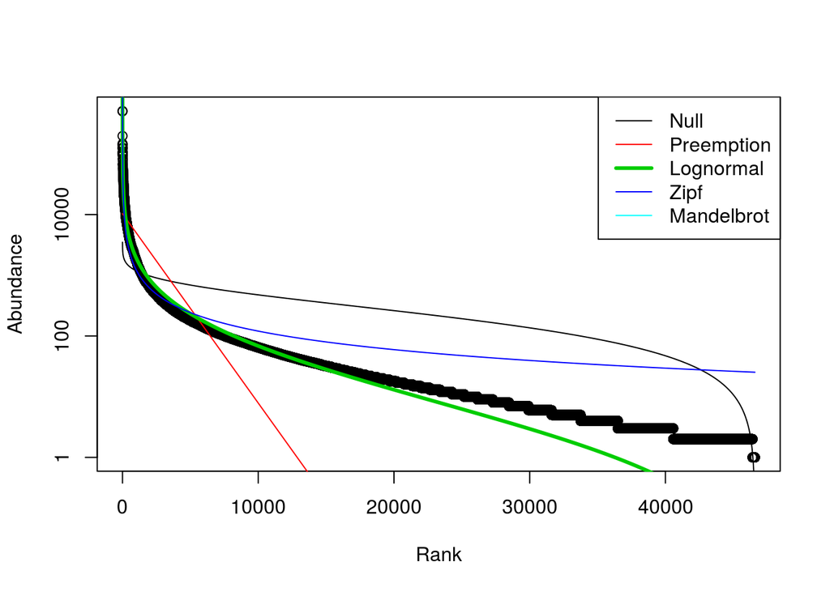

#### 1.3.4.2) Preston’s Lognormal Model

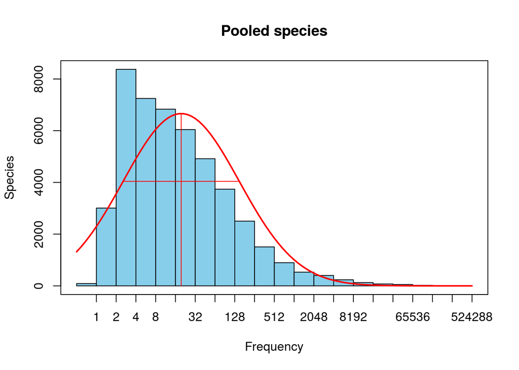

```r
tb18_tax_occur_ss8522_prestonfit<-prestonfit(colSums(tb18_tax_occur_min8522_t))
plot(tb18_tax_occur_ss8522_prestonfit, main="Pooled species")
```

```r
veiledspec(tb18_tax_occur_ss8522_prestonfit)
```

```
## Extrapolated     Observed       Veiled
##    49081.293    46593.000     2488.293
```

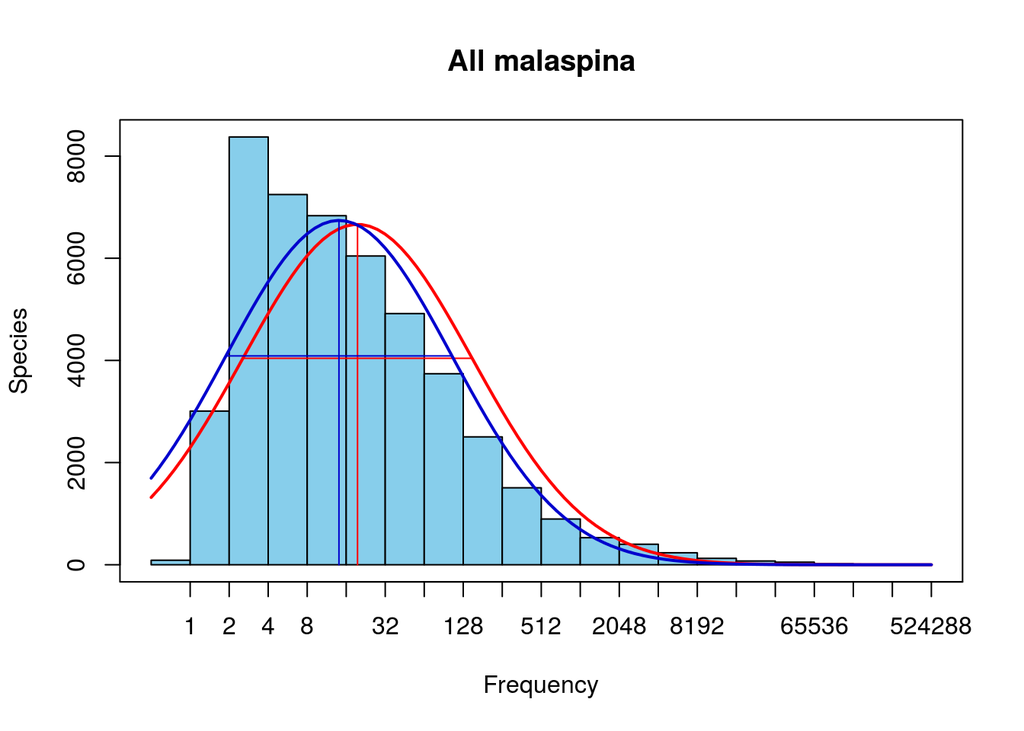

```
## Extrapolated     Observed       Veiled
##    48957.844    46593.000     2364.844
```

### 1.3.6) Beta diversity

#### 1.3.6.1) Dissimilarity matrix using Bray-Curtis index:

The Bray-Curtis dissimilarity, constrained between 0 (minimum distance) and 1 (highest dissimilarity) allows us to quantify the differences between samples according to the composition and relative abundance of their OTUs. In our dataset, most of the samples pairs take dissimilarity values between between 0.7 and 0.8, meaning that their composition is substantially different.

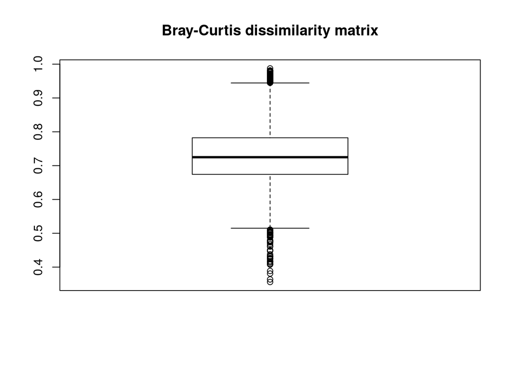

#### 1.3.6.2) Hierarchical clustering

The only relatively evident cluster we can distinguish in the dendogram stands out in the very left side of the plot.

(To be done: assign Longhurst provinces information to each station and check if any of the central clusters is meaningful regarding to the samples’ geographical ubication)

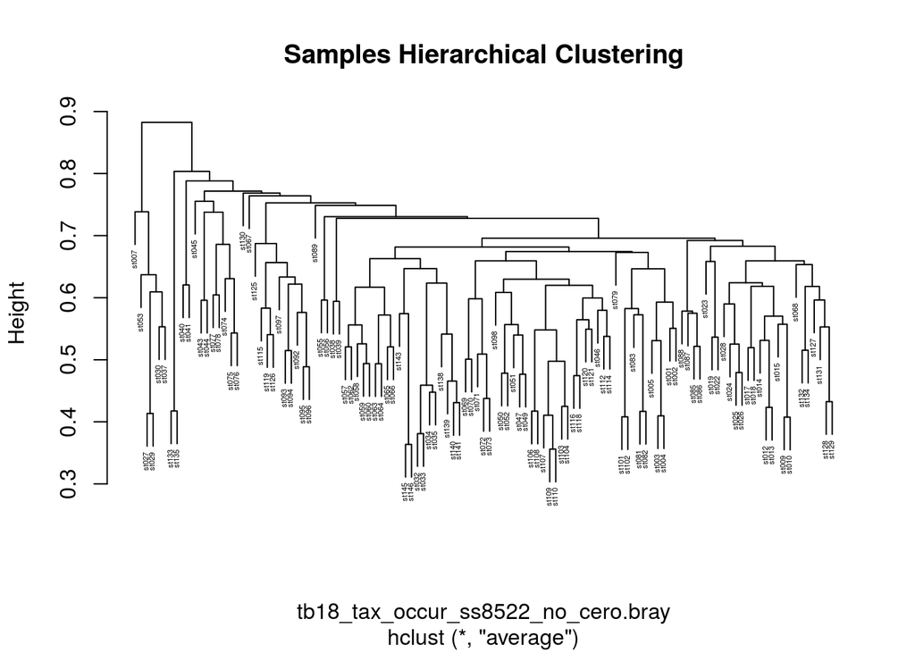

#### 1.3.6.3) Non-metric multidimensional scaling

```
##
## Call:
## monoMDS(dist = tb18_tax_occur_ss8522_no_cero.bray)
##
## Non-metric Multidimensional Scaling
##
## 117 points, dissimilarity 'bray', call 'vegdist(x = tb18_tax_occur_ss8522_no_cero, method = "bray")'
##
## Dimensions: 2
## Stress:     0.2007517
## Stress type 1, weak ties
## Scores scaled to unit root mean square, rotated to principal components
## Stopped after 91 iterations: Stress nearly unchanged (ratio > sratmax)
```

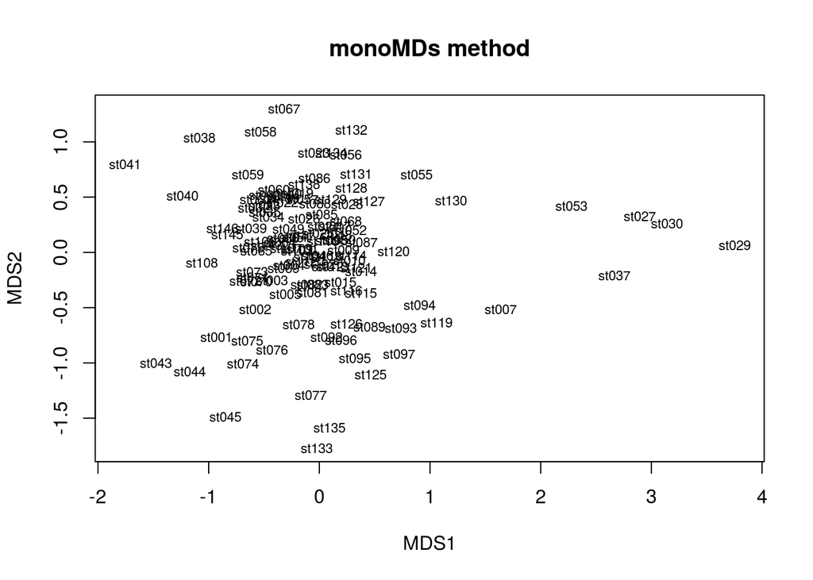

When implementing a most robut function for computing NMDS plots, the result is quiet the same:

```
## ... procrustes: rmse 0.001004021  max resid 0.007828648
## *** Solution reached
```

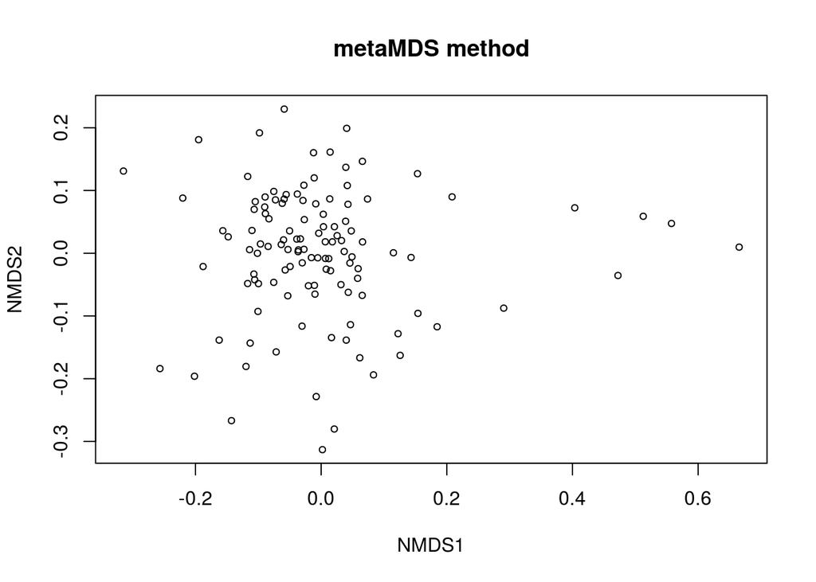

## 1.4) Geographical analysis

Working datasets:

1. Community matrix: tb18_tax_occur_ss8522_no_cero

```r
dim(tb18_tax_occur_ss8522_no_cero)
```

```
## [1]   117 26713
```

```r
tb18_tax_occur_ss8522_no_cero[1:5, 1:5]
```

```
##       OTU_1 OTU_2 OTU_3 OTU_4 OTU_5
## st001    26    25    49     8     0
## st002    23    44   241     3    24
## st003    34   131   237     2    48
## st004    37   189    94   102    31
## st005    24   141    76    32     8
```

2. Community Bray-Curtis: tb18_tax_occur_ss8522_no_cero.bray

```r
tb18_tax_occur_ss8522_no_cero.bray<-as.matrix(tb18_tax_occur_ss8522_no_cero.bray)
```

3. Stations distances in km: geo_distances_MP_18S

```r
dim(geo_distances_MP_18S)
```

```
## [1] 117 117
```

Communities quickly change their composition across geographical distances:

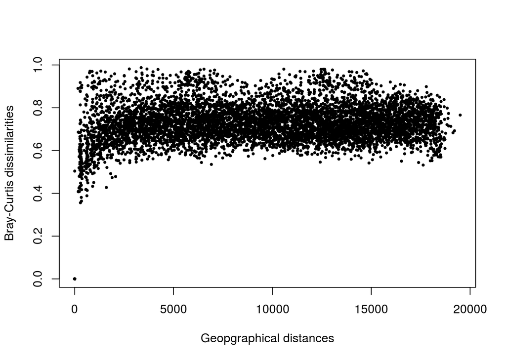

```r
plot(geo_distances_MP_18S, tb18_tax_occur_ss8522_no_cero.bray, pch=19, cex=0.4, xlab="Geopgraphical distances", ylab="Bray-Curtis dissimilarities")
```

### 1.4.1) Mantel correlograms

Mantel statistic is -significantlly- so low, meaning that the correlation between samples dissimilarity and geographical distances is weak.

```r
mantel(geo_distances_MP_18S, tb18_tax_occur_ss8522_no_cero.bray)
```

```
##
## Mantel statistic based on Pearson's product-moment correlation
##
## Call:
## mantel(xdis = geo_distances_MP_18S, ydis = tb18_tax_occur_ss8522_no_cero.bray)
##
## Mantel statistic r: 0.1172
##       Significance: 0.001
##
## Upper quantiles of permutations (null model):
##    90%    95%  97.5%    99%
## 0.0232 0.0296 0.0377 0.0447
## Permutation: free
## Number of permutations: 999
```

Maximum distance between samples:

```
## [1] 19500.19
```

Minimum distance between samples:

```
## [1] 0
```

Correlograms:

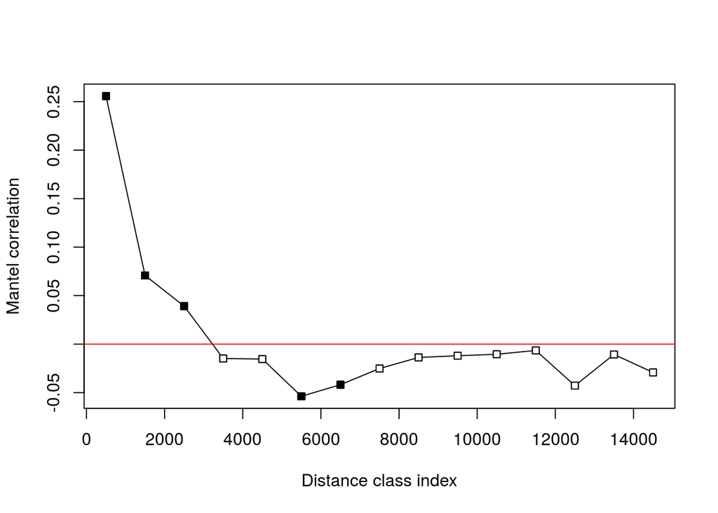

```r
MP_18s_ss8522_mantel_correl_by_1000km<-mantel.correlog(tb18_tax_occur_ss8522_no_cero.bray, D.geo=geo_distances_MP_18S, break.pts=seq(0,20000, by=1000))
plot(MP_18s_ss8522_mantel_correl_by_1000km)
```

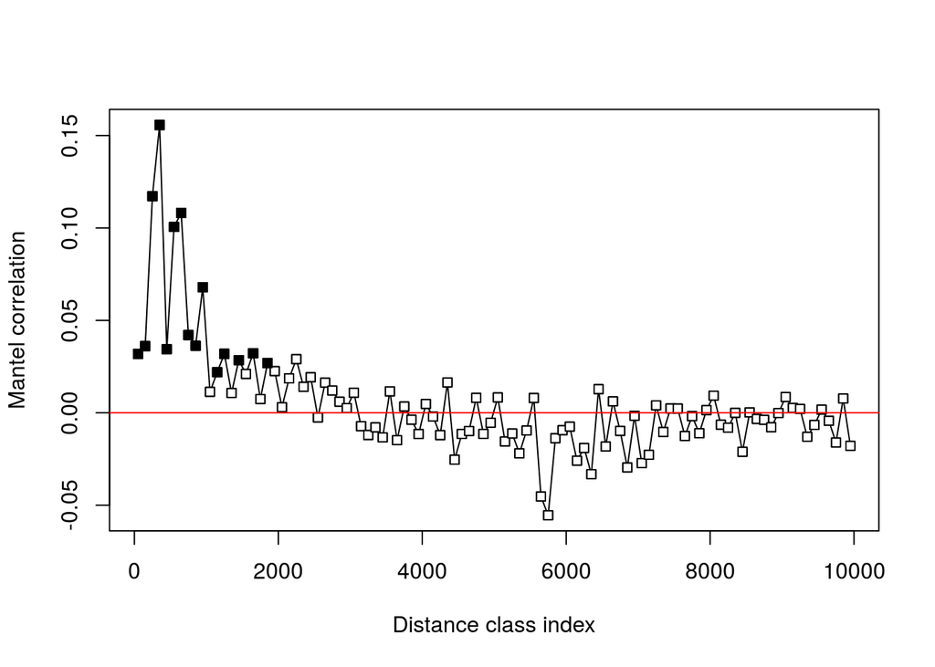

```r
MP_18s_ss8522_mantel_correl_by_100km<-mantel.correlog(tb18_tax_occur_ss8522_no_cero.bray, D.geo=geo_distances_MP_18S, break.pts=seq(0,20000, by=100))
plot(MP_18s_ss8522_mantel_correl_by_100km)
```

## 1.5) Abundance vs. occurence

In the following plot, we can appreciate the OTUs distribution according to their percentage of occurence and relative abundance. The red line keeps up OTUs that occur in more than 80% of the samples, the green line limits regionally rare OTUs (< 0.001%), and the blue one restricts regionally abundant OTUs (> 0.1%).

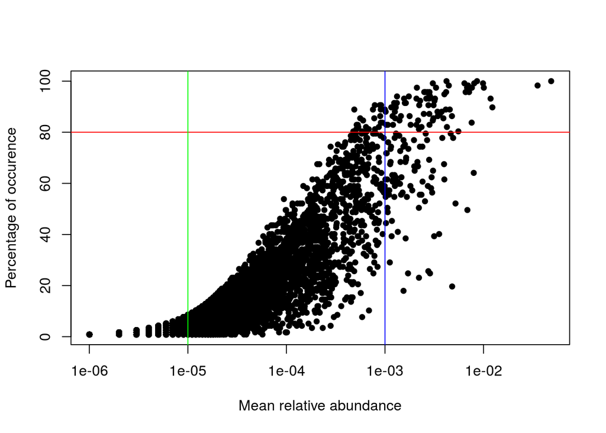

Regionally abundant OTUs (relative abundance over 0.1%):

```
##           mean_rabund perc_occur
## OTU_2     0.048581148  100.00000
## OTU_6     0.035359462   98.29060
## OTU_23    0.012299990   89.74359
## OTU_8     0.011794511   93.16239
## OTU_25    0.010073475   97.43590
## OTU_27    0.009878906   99.14530
## OTU_1     0.008593144  100.00000
## OTU_12    0.008045541   99.14530
## OTU_9     0.007960292   64.10256
## OTU_7     0.007622303   97.43590
## OTU_14696 0.007580180   83.76068
## OTU_13    0.007133874   95.72650
## OTU_4     0.006976413   98.29060
## OTU_20    0.006860073   49.57265
## OTU_11    0.006806917   97.43590
## OTU_24    0.006582260   95.72650
## OTU_18    0.006405743   99.14530
## OTU_3     0.005555255   80.34188
## OTU_34    0.005196204   52.13675
## OTU_5     0.004919394   77.77778
## OTU_119   0.004804057   19.65812
## OTU_21    0.004780989   86.32479
## OTU_22    0.004643587   79.48718
## OTU_26    0.004545300   88.88889
## OTU_45    0.004444003   98.29060
## OTU_10    0.004252443   82.05128
## OTU_64    0.004210319  100.00000
## OTU_19    0.004174214   95.72650
## OTU_17    0.004143123   88.88889
## OTU_40    0.004006724   94.87179
## OTU_58    0.004004718   61.53846
## OTU_70    0.003977639   67.52137
## OTU_36    0.003915457   85.47009
## OTU_106   0.003816166   77.77778
## OTU_50    0.003762008   88.03419
## OTU_28    0.003607556   87.17949
## OTU_44    0.003544371   40.17094
## OTU_14    0.003438060   86.32479
## OTU_5618  0.003410981   88.03419
```

[output cut: 108 more lines]

```
## OTU_141   0.001099216   55.55556
## OTU_11833 0.001077152   76.06838
## OTU_338   0.001069128   82.90598
## OTU_1819  0.001066119   48.71795
## OTU_180   0.001064114   57.26496
## OTU_133   0.001058096   50.42735
## OTU_163   0.001056090   61.53846
## OTU_140   0.001042049   71.79487
## OTU_151   0.001040043   57.26496
## OTU_7573  0.001031017   82.90598
## OTU_235   0.001030014   71.79487
## OTU_136   0.001023996   44.44444
## OTU_130   0.001015973   88.03419
## OTU_129   0.001015973   54.70085
## OTU_123   0.001009955   61.53846
```

```r
dim(tb18_ss8522_abundant_sorted)
```

```
## [1] 162   2
```

Proportion of regionally abundant OTUs (%):

```
## [1] 0.6430868
```

Cosmopolitan OTUs (relative abundance over 0.1% and occurence in more than 80% of samples):

```
##           mean_rabund perc_occur
## OTU_2     0.048581148  100.00000
## OTU_1     0.008593144  100.00000
## OTU_64    0.004210319  100.00000
## OTU_27    0.009878906   99.14530
## OTU_12    0.008045541   99.14530
## OTU_18    0.006405743   99.14530
## OTU_39    0.003058950   99.14530
## OTU_6     0.035359462   98.29060
## OTU_4     0.006976413   98.29060
## OTU_45    0.004444003   98.29060
## OTU_25    0.010073475   97.43590
## OTU_7     0.007622303   97.43590
## OTU_11    0.006806917   97.43590
## OTU_55    0.003296646   97.43590
## OTU_11454 0.002108169   97.43590
## OTU_13    0.007133874   95.72650
## OTU_24    0.006582260   95.72650
## OTU_19    0.004174214   95.72650
## OTU_35799 0.002829278   95.72650
## OTU_29    0.002699900   95.72650
## OTU_49    0.002573530   95.72650
## OTU_71    0.002504328   95.72650
## OTU_40    0.004006724   94.87179
## OTU_72    0.002806211   94.87179
## OTU_33    0.002870399   94.01709
## OTU_126   0.001746109   94.01709
## OTU_243   0.001324877   94.01709
## OTU_8     0.011794511   93.16239
## OTU_31    0.003216411   93.16239
## OTU_65    0.002804205   93.16239
## OTU_75    0.002624680   93.16239
## OTU_78    0.002087107   93.16239
## OTU_121   0.001562572   93.16239
## OTU_42    0.003177297   92.30769
## OTU_66    0.002274656   92.30769
## OTU_90    0.001628766   91.45299
## OTU_67    0.001590654   91.45299
## OTU_1136  0.001319862   91.45299
## OTU_188   0.001239627   91.45299
```

[output cut: 22 more lines]

```
## OTU_177   0.001268712   85.47009
## OTU_51    0.003056945   84.61538
## OTU_54    0.002168345   84.61538
## OTU_112   0.001404108   84.61538
## OTU_14696 0.007580180   83.76068
## OTU_48    0.002829278   82.90598
## OTU_6315  0.002086104   82.90598
## OTU_87    0.001822332   82.90598
## OTU_192   0.001206530   82.90598
## OTU_338   0.001069128   82.90598
## OTU_7573  0.001031017   82.90598
## OTU_10    0.004252443   82.05128
## OTU_85    0.002348873   82.05128
## OTU_76    0.002211471   81.19658
## OTU_3     0.005555255   80.34188
```

```r
dim(otu_tb18_ss8522_cosmop_sorted)
```

```
## [1] 76  2
```

Proportion of cosmopolitan OTUs (%):

```
## [1] 0.254059
```

Number and proportion (%) of rare OTUs:

```r
dim(otu_tb18_ss8522_rabund_percoccur[otu_tb18_ss8522_rabund_percoccur$mean_rabund < 0.00001 & otu_tb18_ss8522_rabund_percoccur$mean_rabund >0,])
```

```
## [1] 20730     2
```

```
## [1] 73.64138
```